# CI and Bootstrap Homework - Week 6 - Day 3

**1 MVP** Now we’ll go back to CI creation in the normal fashion. We’ll take the ames data from the CIs lab earlier today and regard it now as a sample, we won’t be drawing any smaller samples from within it. This is the usual situation in an analysis: you use all the data available to you!

```r
library(tidyverse)
library(infer)
library(janitor)
library(here)
```

**Task 1.** Load the data again, clean_names(), and re-familiarise yourself with it

```r
ames <- read_csv("data/ames.csv") %>%
  clean_names()
glimpse(ames)
```

```
Rows: 2,930
Columns: 82
$ order           <dbl> 1, 2, 3, 4, 5, 6, 7, 8, 9, 10, 11, 12, 13, 14, 15, 16, 17, 18, 19, 20, 21, 22, 23, 24, 25, 26, 27, 28, 29, 30, 31~
$ pid             <dbl> 526301100, 526350040, 526351010, 526353030, 527105010, 527105030, 527127150, 527145080, 527146030, 527162130, 527~
$ ms_sub_class    <dbl> 20, 20, 20, 20, 60, 60, 120, 120, 120, 60, 60, 20, 60, 20, 120, 60, 50, 20, 20, 20, 20, 85, 60, 20, 20, 20, 20, 2~
$ ms_zoning       <chr> "RL", "RH", "RL", "RL", "RL", "RL", "RL", "RL", "RL", "RL", "RL", "RL", "RL", "RL", "RL", "RL", "RL", "RL", "RL",~
$ lot_frontage    <dbl> 141, 80, 81, 93, 74, 78, 41, 43, 39, 60, 75, NA, 63, 85, NA, 47, 152, 88, 140, 85, 105, 85, NA, NA, NA, 65, 70, 7~
$ lot_area        <dbl> 31770, 11622, 14267, 11160, 13830, 9978, 4920, 5005, 5389, 7500, 10000, 7980, 8402, 10176, 6820, 53504, 12134, 11~
$ street          <chr> "Pave", "Pave", "Pave", "Pave", "Pave", "Pave", "Pave", "Pave", "Pave", "Pave", "Pave", "Pave", "Pave", "Pave", "~
$ alley           <chr> NA, NA, NA, NA, NA, NA, NA, NA, NA, NA, NA, NA, NA, NA, NA, NA, NA, NA, NA, NA, NA, NA, NA, NA, NA, NA, NA, NA, N~
$ lot_shape       <chr> "IR1", "Reg", "IR1", "Reg", "IR1", "IR1", "Reg", "IR1", "IR1", "Reg", "IR1", "IR1", "IR1", "Reg", "IR1", "IR2", "~
$ land_contour    <chr> "Lvl", "Lvl", "Lvl", "Lvl", "Lvl", "Lvl", "Lvl", "HLS", "Lvl", "Lvl", "Lvl", "Lvl", "Lvl", "Lvl", "Lvl", "HLS", "~
$ utilities       <chr> "AllPub", "AllPub", "AllPub", "AllPub", "AllPub", "AllPub", "AllPub", "AllPub", "AllPub", "AllPub", "AllPub", "Al~
$ lot_config      <chr> "Corner", "Inside", "Corner", "Corner", "Inside", "Inside", "Inside", "Inside", "Inside", "Inside", "Corner", "In~
$ land_slope      <chr> "Gtl", "Gtl", "Gtl", "Gtl", "Gtl", "Gtl", "Gtl", "Gtl", "Gtl", "Gtl", "Gtl", "Gtl", "Gtl", "Gtl", "Gtl", "Mod", "~
```

[output cut: 69 more lines]

**Task 2.** Investigate the distribution of lot_area. Is the distribution roughly normal? If not, what problems do you find?

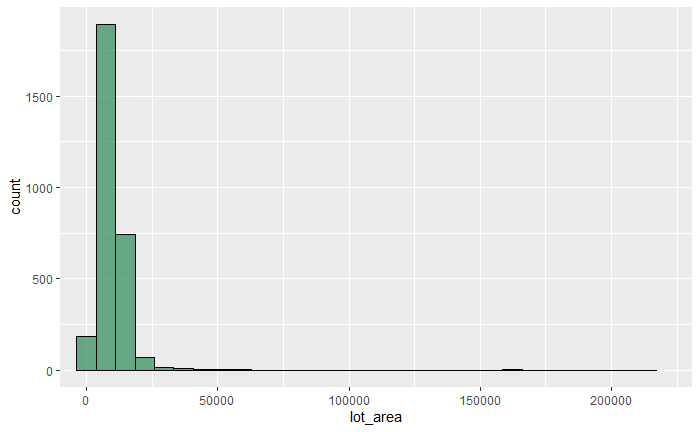

```r
ames %>%
  ggplot() +
  aes(x = lot_area) +
  geom_histogram(fill = "sea green", col = "black", alpha = 0.7)+
  coord_cartesian(xlim = c(1000, 220000))
```

```r
# lot_area is right skewed
# if I put col="white" in the geom_histogram, you can't really see the full
# extent of the right skew.
```

**Task 3.** Compute and visualise a bootstrap sampling distribution for the mean(lot_area) of the sold houses.

```r
# we're not taking smaller samples so is the sample size 2930? (there are 2930
# rows)
# my computer won't run 2930 happily, it keeps terminating. so I'll try with
# 2000 (which took at least a minute):

bootstrap_sampling <- ames %>%
  rep_sample_n(size = 2000, replace = TRUE, reps = 5000) %>%
  summarise(
    mean_lot_area = mean(lot_area)
  )

bootstrap_sampling
```

| replicate | mean_lot_area |
| --- | --- |
| 1 | 9825.281 |
| 2 | 9983.842 |
| 3 | 10313.718 |
| 4 | 10390.025 |
| 5 | 10051.413 |
| 6 | 10053.165 |
| 7 | 10073.111 |
| 8 | 10200.492 |
| 9 | 10293.291 |
| 10 | 10188.532 |

[output cut: 990 more lines]

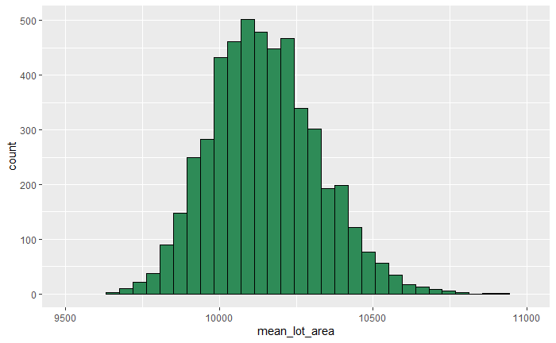

```r
bootstrap_sampling_hist <- bootstrap_sampling %>%
  ggplot() +
  aes(x = mean_lot_area) +
  geom_histogram(fill = "sea green", col = "black")+
  coord_cartesian(xlim = c(9500, 11000))
bootstrap_sampling_hist
```

**Task 4.** Use your bootstrap distribution to calculate a 95% CI for mean(lot_area), and visualise it on the distribution

```r
# ci_95 <- bootstrap_sampling %>%
#   summarise(
#     mean = mean(mean_lot_area),
#     lower_bound = quantile(mean_lot_area, probs = 0.025),
#     upper_bound = quantile(mean_lot_area, probs = 0.975)
#   )
#
# ci_95
# Mean = 10,145.5
# Lower Bound = 9,830.748
# Upper Bound = 10,516.35



infer_resample <- ames %>%
  #which variable we are interested in
  specify(response = lot_area) %>%
  #generate the replicates to resample
  generate(reps = 5000, type = "bootstrap") %>%
  # statistic we are interested in for each resample
  calculate(stat = "mean")

infer_resample
```

```
Response: lot_area (numeric)
```

| replicate | stat |
| --- | --- |
| 1 | 10182.552 |
| 2 | 10247.463 |
| 3 | 10097.940 |
| 4 | 10155.924 |
| 5 | 10072.317 |
| 6 | 9917.022 |
| 7 | 10406.083 |
| 8 | 10053.935 |
| 9 | 10262.915 |
| 10 | 10075.854 |

[output cut: 990 more lines]

```r
infer_ci_95 <- infer_resample %>%
  get_confidence_interval(level = 0.95, type = "percentile")

infer_ci_95
```

| lower_ci | upper_ci |
| --- | --- |
| 9890.005 | 10445.63 |

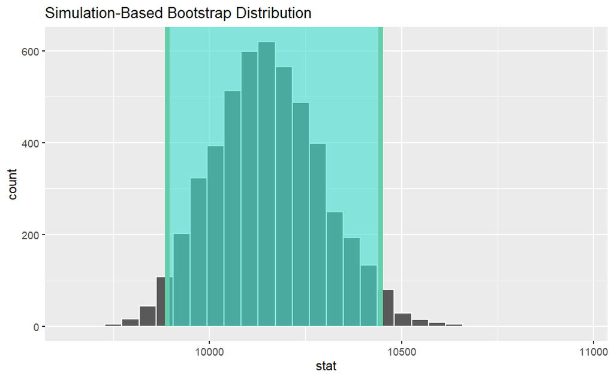

```r
# lower ci = 9,871.338
# upper ci = 10,446.97


infer_resample %>%
  visualise(bins = 30) +
  shade_confidence_interval(endpoints = infer_ci_95)
```

Task 5. You would like to know the mean(lot_area) of the sold houses with higher confidence. Calculate the 99% CI for this variable (you can re-use your bootstrap distribution from above). Is it narrower or broader than the 95% CI? Does that make sense?

```r
infer_resample <- ames %>%
  #which variable we are interested in
  specify(response = lot_area) %>%
  #generate the replicates to resample
  generate(reps = 5000, type = "bootstrap") %>%
  # statistic we are interested in for each resample
  calculate(stat = "mean")

infer_resample
```

```
Response: lot_area (numeric)
```

| replicate | stat |
| --- | --- |
| 1 | 10173.463 |
| 2 | 10034.238 |
| 3 | 10330.017 |
| 4 | 10208.384 |
| 5 | 10044.280 |
| 6 | 10291.426 |
| 7 | 9993.521 |
| 8 | 10240.497 |
| 9 | 9981.157 |
| 10 | 10316.734 |

[output cut: 990 more lines]

```r
infer_ci_99 <- infer_resample %>%
  get_confidence_interval(level = 0.99, type = "percentile")

infer_ci_99
```

| lower_ci | upper_ci |
| --- | --- |
| 9808.956 | 10539.27 |

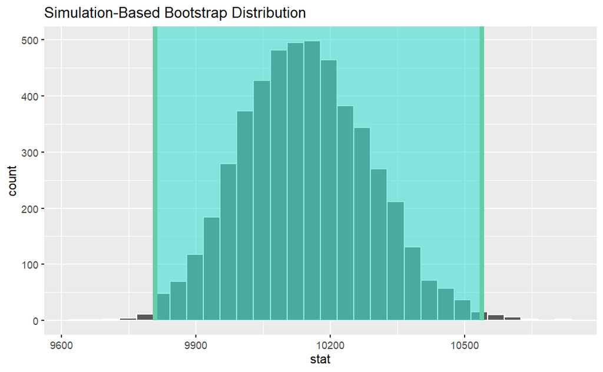

```r
# lower ci = 9,789.697
# upper ci = 10,523.41


infer_resample %>%
  visualise(bins = 30) +
  shade_confidence_interval(endpoints = infer_ci_99)
```

```r
# The 99% CI is broader. This does make sense as the wider the sample (?) the
# more we chances we give ourselves of having the mean included
```

Task 6. Calculate the point estimate of the mean(lot_area)

```r
point_estimate_lot_area <- ames %>%
  rep_sample_n(size = 2930, reps = 1) %>%
  summarise(
    mean_lot_area = mean(lot_area)
  )

point_estimate_lot_area
```

| replicate | mean_lot_area |
| --- | --- |
| 1 | 10147.92 |

```r
# The mean for lot_area is 10,147.92
```

2 Extension

Task 1. Calculate a point estimate and 95% CI for the proportion of houses in the data built before 1920. Does the number of reps you use matter? [Investigate reps from 200 up to 50000, memory of your laptop permitting].

oops… i thought i finished this!

```r
built_before_1920 <- ames %>%
  filter(year_built <= 1920)
built_before_1920
```

| order | pid | ms_sub_class | ms_zoning | lot_frontage | lot_area | street | alley | lot_shape | land_contour | utilities | lot_config | land_slope | neighborhood | condition_1 | condition_2 | bldg_type | house_style | overall_qual | overall_cond | year_built | year_remod_add | roof_style | roof_matl | exterior_1st | exterior_2nd | mas_vnr_type | mas_vnr_area | exter_qual | exter_cond | … |
| --- | --- | --- | --- | --- | --- | --- | --- | --- | --- | --- | --- | --- | --- | --- | --- | --- | --- | --- | --- | --- | --- | --- | --- | --- | --- | --- | --- | --- | --- | --- |
| 83 | 531477050 | 30 | RH | 70 | 9800 | Pave | NA | Reg | Lvl | AllPub | Corner | Gtl | SawyerW | Feedr | Norm | 1Fam | 1Story | 5 | 5 | 1920 | 1950 | Gable | CompShg | Wd Sdng | Wd Sdng | None | 0 | TA | Fa | … |
| 154 | 535325400 | 30 | RL | 65 | 7898 | Pave | NA | Reg | Lvl | AllPub | Corner | Gtl | NAmes | Norm | Norm | 1Fam | 1Story | 4 | 7 | 1920 | 1994 | Gable | CompShg | MetalSd | MetalSd | None | 0 | TA | TA | … |
| 170 | 902102100 | 50 | RM | 60 | 4800 | Pave | NA | Reg | Lvl | AllPub | Corner | Gtl | OldTown | Norm | Norm | 1Fam | 1.5Fin | 4 | 5 | 1900 | 1954 | Hip | CompShg | Wd Sdng | Wd Sdng | BrkFace | 771 | TA | TA | … |
| 171 | 902104060 | 50 | RM | 55 | 8800 | Pave | Grvl | Reg | Lvl | AllPub | Corner | Gtl | OldTown | Norm | Norm | 1Fam | 1.5Fin | 4 | 7 | 1910 | 2004 | Gable | CompShg | Wd Sdng | Wd Sdng | None | 0 | TA | TA | … |
| 172 | 902106130 | 30 | RM | 56 | 4485 | Pave | Grvl | Reg | Lvl | AllPub | Inside | Gtl | OldTown | Artery | Norm | 1Fam | 1Story | 5 | 7 | 1920 | 1950 | Gable | CompShg | Wd Sdng | Wd Sdng | None | 0 | TA | TA | … |
| 175 | 902125080 | 50 | RM | 60 | 5790 | Pave | NA | Reg | Lvl | AllPub | Corner | Gtl | OldTown | Norm | Norm | 1Fam | 2Story | 3 | 6 | 1915 | 1950 | Gambrel | CompShg | VinylSd | VinylSd | None | 0 | Gd | Gd | … |
| 181 | 902206240 | 50 | RM | NA | 8239 | Pave | NA | Reg | Lvl | AllPub | Inside | Gtl | OldTown | Artery | Norm | 1Fam | 1.5Fin | 5 | 6 | 1920 | 1962 | Gable | CompShg | MetalSd | MetalSd | None | 0 | TA | TA | … |
| 184 | 902305110 | 70 | RM | 60 | 9600 | Pave | Grvl | Reg | Lvl | AllPub | Corner | Gtl | OldTown | Norm | Norm | 1Fam | 2Story | 8 | 9 | 1900 | 2003 | Gable | CompShg | Wd Sdng | Wd Sdng | None | 0 | Gd | Gd | … |
| 185 | 902327040 | 50 | RM | 60 | 10800 | Pave | NA | Reg | Lvl | AllPub | Inside | Gtl | OldTown | Artery | Norm | 1Fam | 1.5Fin | 5 | 6 | 1915 | 1950 | Gable | CompShg | MetalSd | MetalSd | None | 0 | TA | Gd | … |
| 186 | 902329030 | 70 | RM | 50 | 9000 | Pave | Grvl | Reg | Lvl | AllPub | Inside | Gtl | OldTown | Norm | Norm | 1Fam | 2Story | 8 | 9 | 1890 | 2002 | Gable | CompShg | Wd Sdng | Wd Sdng | None | 0 | Gd | Gd | … |

[output cut: 223 more lines]

```r
#there are 233 of them

point_estimate_1920 <- built_before_1920 %>%
  rep_sample_n(size = 233, reps = 200) %>%
  summarise(
    mean_lot_area = mean(lot_area)
  )

point_estimate_1920
```

| replicate | mean_lot_area |
| --- | --- |
| 1 | 9469.785 |
| 2 | 9469.785 |
| 3 | 9469.785 |
| 4 | 9469.785 |
| 5 | 9469.785 |
| 6 | 9469.785 |
| 7 | 9469.785 |
| 8 | 9469.785 |
| 9 | 9469.785 |
| 10 | 9469.785 |

[output cut: 190 more lines]

```r
point_estimate_1920_more_reps <- built_before_1920 %>%
  rep_sample_n(size = 233, reps = 1000) %>%
  summarise(
    mean_lot_area = mean(lot_area)
  )

point_estimate_1920_more_reps
```

| replicate | mean_lot_area |
| --- | --- |
| 1 | 9469.785 |
| 2 | 9469.785 |
| 3 | 9469.785 |
| 4 | 9469.785 |
| 5 | 9469.785 |
| 6 | 9469.785 |
| 7 | 9469.785 |
| 8 | 9469.785 |
| 9 | 9469.785 |
| 10 | 9469.785 |

[output cut: 990 more lines]